# Визуальная оценка взаимосвязи между числом НЯ и собранными признаками пациентов

# Подготовка

```r
library(tidyverse)
library(patchwork)
library(gghighlight)
library(readr)
library(dplyr)
library(ggplot2)
```

```r
crohn <- read_csv("data/CrohnD.csv", show_col_types = FALSE)
```

```r
crohn$sex <- factor(crohn$sex, levels = c("F", "M"))
crohn$country <- factor(crohn$country, levels = c("c1", "c2"))
crohn$treat <- factor(crohn$treat, levels = c("placebo", "d1", "d2"))
```

```r
dim(crohn)
```

```
[1] 117  10
```

```r
colSums(is.na(crohn))
```

```
rownames       ID   nrAdvE      BMI   height  country      sex      age
       0        0        0        0        0        0        0        0
  weight    treat
       0        0
```

В файле 117 пациентов. Число НЯ изменяется от 0 до 12. Пропусков в используемых столбцах нет. Поэтому важно показать отдельные наблюдения, а не только средние значения. Для числовых признаков выбрала диаграммы рассеяния, для категориальных — боксплоты с точками пациентов. Это позволяет увидеть возможные тенденции, разброс, перекрытие распределений и крайние наблюдения.

```r
theme_set(theme_minimal(base_size = 12))
```

Обозначения групп: F — женщины, M — мужчины; placebo — плацебо, d1 — препарат 1, d2 — препарат 2. Страны оставляем под кодами c1 и c2: их названия не указаны.

1. Зависимость от числовых признаков.

Числовые признаки(возраст, BMI, рост, вес)

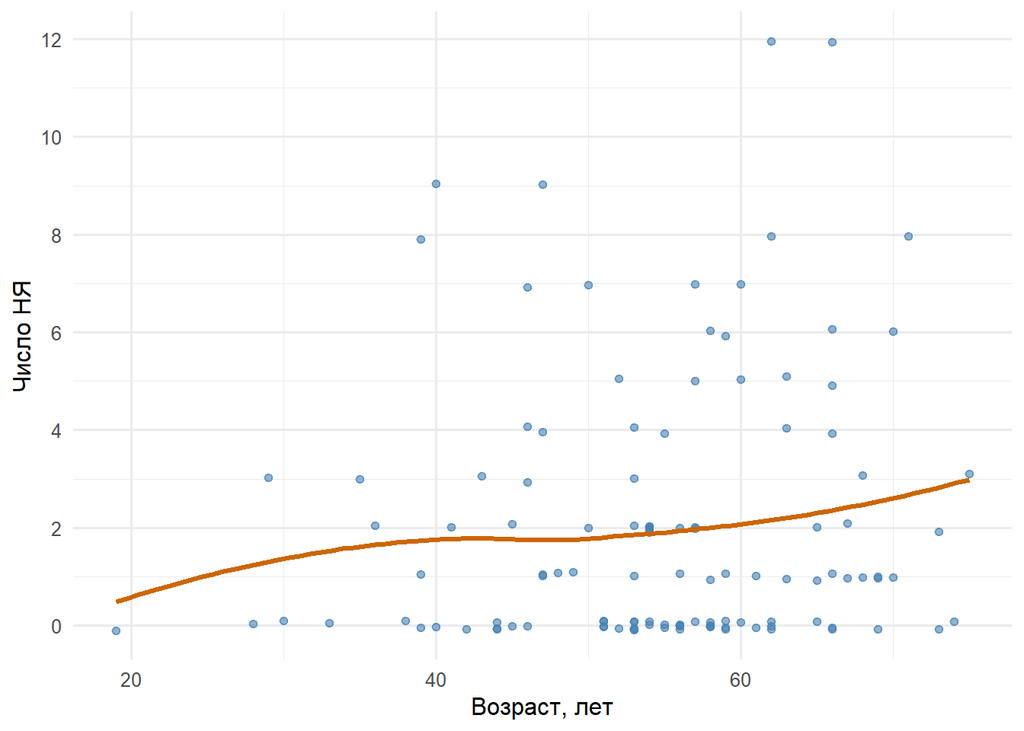

```r
p_age <- ggplot(crohn, aes(x = age, y = nrAdvE)) +
  geom_point(
    position = position_jitter(width = 0, height = 0.1, seed = 123),
    alpha = 0.6,
    colour = "steelblue"
  ) +
  geom_smooth(method = "loess", span = 1, se = FALSE, colour = "darkorange3") +
  scale_y_continuous(breaks = seq(0, max(crohn$nrAdvE), by = 2)) +
  labs(x = "Возраст, лет", y = "Число НЯ")

p_age
```

Отмечается слабая восходящая тенденция, но значения сильно разбросаны. При разных возрастах встречаются пациенты без НЯ; чёткой зависимости по графику не видно.

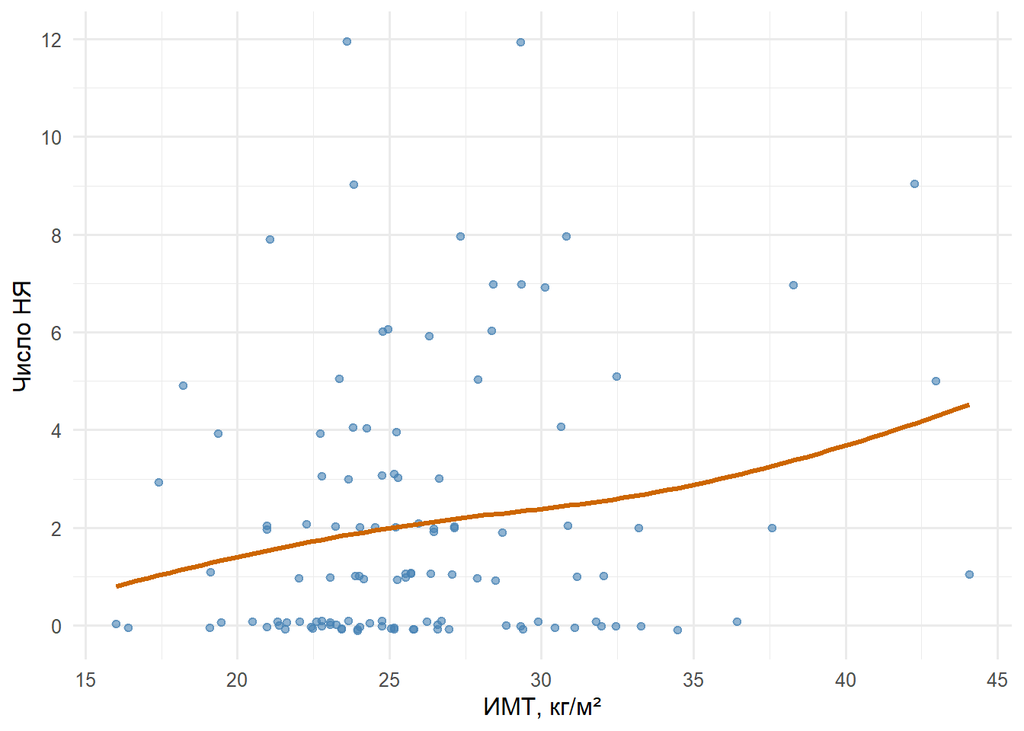

```r
p_bmi <- ggplot(crohn, aes(x = BMI, y = nrAdvE)) +
  geom_point(
    position = position_jitter(width = 0, height = 0.1, seed = 123),
    alpha = 0.6,
    colour = "steelblue"
  ) +
  geom_smooth(method = "loess", span = 1, se = FALSE, colour = "darkorange3") +
  scale_y_continuous(breaks = seq(0, max(crohn$nrAdvE), by = 2)) +
  labs(x = "ИМТ, кг/м²", y = "Число НЯ")

p_bmi
```

Линия сглаживания указывает на возможное увеличение числа НЯ с ростом ИМТ. Однако разброс велик, а при высоком ИМТ пациентов мало, поэтому тенденцию следует оценивать осторожно.

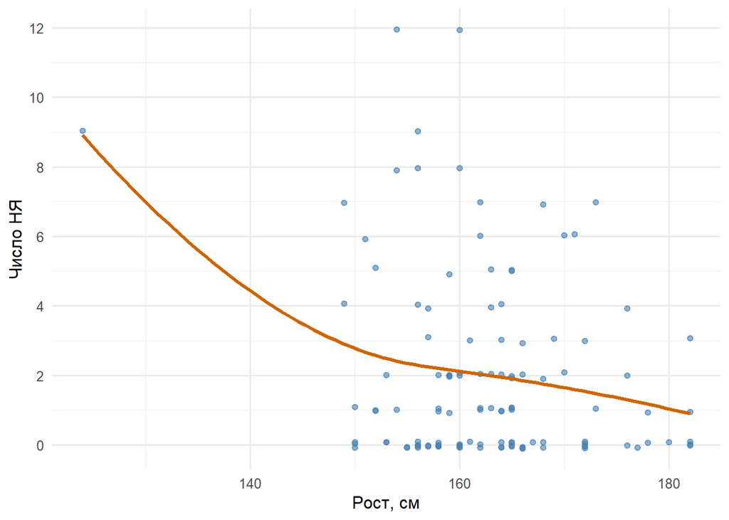

```r
p_height <- ggplot(crohn, aes(x = height, y = nrAdvE)) +
  geom_point(
    position = position_jitter(width = 0, height = 0.1, seed = 123),
    alpha = 0.6,
    colour = "steelblue"
  ) +
  geom_smooth(method = "loess", span = 1, se = FALSE, colour = "darkorange3") +
  scale_y_continuous(breaks = seq(0, max(crohn$nrAdvE), by = 2)) +
  labs(x = "Рост, см", y = "Число НЯ")

p_height
```

Сглаженная линия снижается, но на её левую часть влияет отдельный пациент с ростом 124 см и 9 НЯ (ID = 28911). Значение роста желательно проверить по первоисточнику. Без такой проверки запись не изменяем и не исключаем.

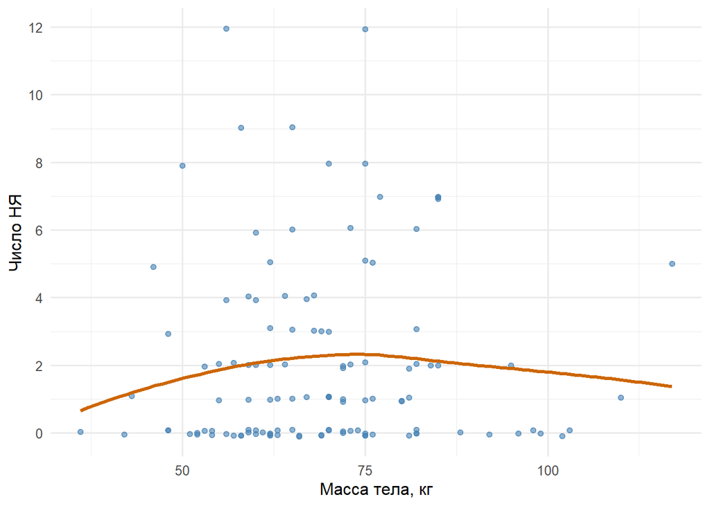

```r
p_weight <- ggplot(crohn, aes(x = weight, y = nrAdvE)) +
  geom_point(
    position = position_jitter(width = 0, height = 0.1, seed = 123),
    alpha = 0.6,
    colour = "steelblue"
  ) +
  geom_smooth(method = "loess", span = 1, se = FALSE, colour = "darkorange3") +
  scale_y_continuous(breaks = seq(0, max(crohn$nrAdvE), by = 2)) +
  labs(x = "Масса тела, кг", y = "Число НЯ")

p_weight
```

Выраженной монотонной связи числа НЯ с массой тела не видно. При разных значениях массы встречаются как нулевые, так и более высокие числа НЯ.

2. Зависимость от категориальных признаков. Категориальные признаки(пол, страна, лечение)

```r
table(crohn$sex)
```

```
  F   M
100  17
```

В датафрейме 100 женщин и 17 мужчин.

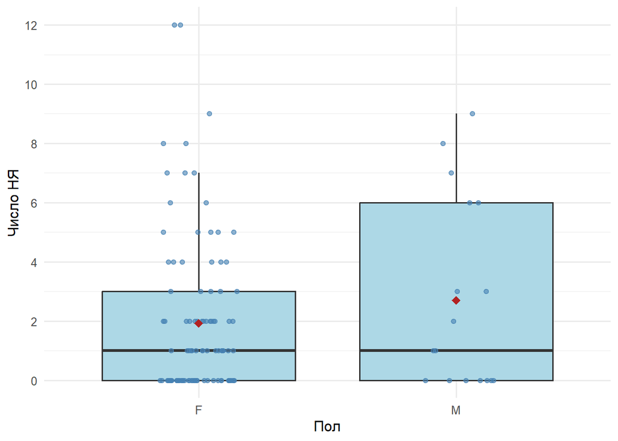

```r
p_sex <- ggplot(crohn, aes(x = sex, y = nrAdvE)) +
  geom_boxplot(fill = "lightblue", outlier.shape = NA) +
  geom_point(
    position = position_jitter(width = 0.15, height = 0, seed = 123),
    alpha = 0.6,
    colour = "steelblue"
  ) +
  stat_summary(
    fun = mean,
    geom = "point",
    shape = 18,
    size = 3,
    colour = "firebrick"
  ) +
  scale_y_continuous(breaks = seq(0, max(crohn$nrAdvE), by = 2)) +
  labs(x = "Пол", y = "Число НЯ")

p_sex
```

В группе мужчин среднее выше, но медиана в обеих группах равна 1. Мужчин в выборке значительно меньше, поэтому сравнение чувствительно к отдельным высоким значениям.

```r
table(crohn$country)
```

```
c1 c2
78 39
```

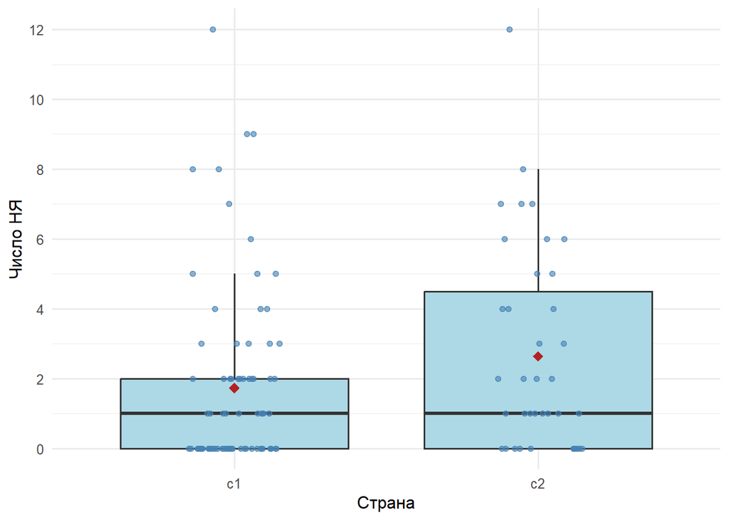

```r
p_country <- ggplot(crohn, aes(x = country, y = nrAdvE)) +
  geom_boxplot(fill = "lightblue", outlier.shape = NA) +
  geom_point(
    position = position_jitter(width = 0.15, height = 0, seed = 123),
    alpha = 0.6,
    colour = "steelblue"
  ) +
  stat_summary(
    fun = mean,
    geom = "point",
    shape = 18,
    size = 3,
    colour = "firebrick"
  ) +
  scale_y_continuous(breaks = seq(0, max(crohn$nrAdvE), by = 2)) +
  labs(x = "Страна", y = "Число НЯ")

p_country
```

У пациентов из c2 среднее выше и верхняя часть распределения шире, чем в c1. Медианы обеих групп равны 1, распределения существенно перекрываются.

```r
table(crohn$treat)
```

```
placebo      d1      d2
     39      39      39
```

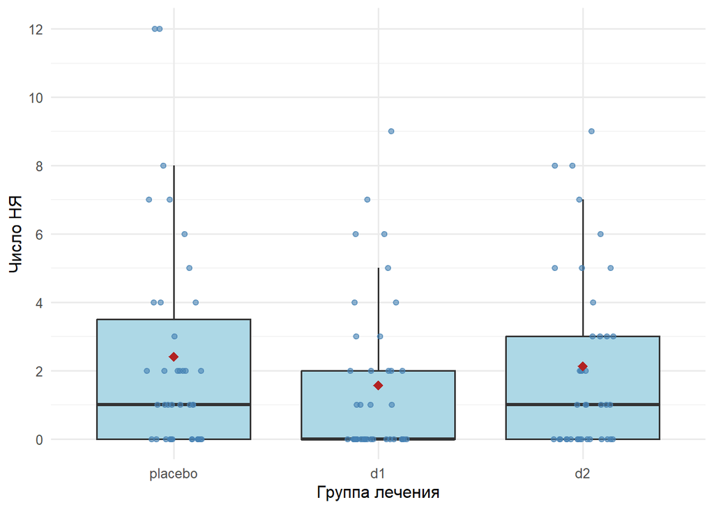

```r
p_treat <- ggplot(crohn, aes(x = treat, y = nrAdvE)) +
  geom_boxplot(fill = "lightblue", outlier.shape = NA) +
  geom_point(
    position = position_jitter(width = 0.15, height = 0, seed = 123),
    alpha = 0.6,
    colour = "steelblue"
  ) +
  stat_summary(
    fun = mean,
    geom = "point",
    shape = 18,
    size = 3,
    colour = "firebrick"
  ) +
  scale_y_continuous(breaks = seq(0, max(crohn$nrAdvE), by = 2)) +
  labs(x = "Группа лечения", y = "Число НЯ")

p_treat
```

В d1 медиана равна 0, а в placebo и d2 — 1. Среднее в d1 также ниже; d2 занимает промежуточное положение по среднему. При этом распределения всех трёх групп перекрываются. По рисунку нельзя утверждать, что препарат уменьшает число НЯ: необходима количественная оценка различий и их неопределённости.

```r
dir.create("out/figures", recursive = TRUE, showWarnings = FALSE)
ggsave("out/figures/age.png", p_age, width = 8, height = 4.5, dpi = 150)
```

```r
ggsave("out/figures/bmi.png", p_bmi, width = 8, height = 4.5, dpi = 150)
```

```r
ggsave("out/figures/height.png", p_height, width = 8, height = 4.5, dpi = 150)
```

```r
ggsave("out/figures/weight.png", p_weight, width = 8, height = 4.5, dpi = 150)
```

```r
ggsave("out/figures/sex.png", p_sex, width = 8, height = 4.5, dpi = 150)
ggsave("out/figures/country.png", p_country, width = 8, height = 4.5, dpi = 150)
ggsave("out/figures/treatment.png", p_treat, width = 8, height = 4.5, dpi = 150)

writeLines(capture.output(sessionInfo()), "out/session-info.txt")
```